# chapter3

Tiina Autio

2/10/2017

# Analysis of Student Alcohol consumption

Let’s take a look of the data:

```
## [1] 382  35
```

```
##  [1] "school"     "sex"        "age"        "address"    "famsize"
##  [6] "Pstatus"    "Medu"       "Fedu"       "Mjob"       "Fjob"
## [11] "reason"     "nursery"    "internet"   "guardian"   "traveltime"
## [16] "studytime"  "failures"   "schoolsup"  "famsup"     "paid"
## [21] "activities" "higher"     "romantic"   "famrel"     "freetime"
## [26] "goout"      "Dalc"       "Walc"       "health"     "absences"
## [31] "G1"         "G2"         "G3"         "alc_use"    "high_use"
```

```
## 'data.frame':    382 obs. of  35 variables:
##  $ school    : Factor w/ 2 levels "GP","MS": 1 1 1 1 1 1 1 1 1 1 ...
##  $ sex       : Factor w/ 2 levels "F","M": 1 1 1 1 1 2 2 1 2 2 ...
##  $ age       : int  18 17 15 15 16 16 16 17 15 15 ...
##  $ address   : Factor w/ 2 levels "R","U": 2 2 2 2 2 2 2 2 2 2 ...
##  $ famsize   : Factor w/ 2 levels "GT3","LE3": 1 1 2 1 1 2 2 1 2 1 ...
##  $ Pstatus   : Factor w/ 2 levels "A","T": 1 2 2 2 2 2 2 1 1 2 ...
##  $ Medu      : int  4 1 1 4 3 4 2 4 3 3 ...
##  $ Fedu      : int  4 1 1 2 3 3 2 4 2 4 ...
##  $ Mjob      : Factor w/ 5 levels "at_home","health",..: 1 1 1 2 3 4 3 3 4 3 ...
##  $ Fjob      : Factor w/ 5 levels "at_home","health",..: 5 3 3 4 3 3 3 5 3 3 ...
##  $ reason    : Factor w/ 4 levels "course","home",..: 1 1 3 2 2 4 2 2 2 2 ...
##  $ nursery   : Factor w/ 2 levels "no","yes": 2 1 2 2 2 2 2 2 2 2 ...
##  $ internet  : Factor w/ 2 levels "no","yes": 1 2 2 2 1 2 2 1 2 2 ...
##  $ guardian  : Factor w/ 3 levels "father","mother",..: 2 1 2 2 1 2 2 2 2 2 ...
```

[output cut: 21 more lines]

```
##  school   sex          age        address famsize   Pstatus
##  GP:342   F:198   Min.   :15.00   R: 81   GT3:278   A: 38
##  MS: 40   M:184   1st Qu.:16.00   U:301   LE3:104   T:344
##                   Median :17.00
##                   Mean   :16.59
##                   3rd Qu.:17.00
##                   Max.   :22.00
##       Medu            Fedu             Mjob           Fjob
##  Min.   :0.000   Min.   :0.000   at_home : 53   at_home : 16
##  1st Qu.:2.000   1st Qu.:2.000   health  : 33   health  : 17
##  Median :3.000   Median :3.000   other   :138   other   :211
##  Mean   :2.806   Mean   :2.565   services: 96   services:107
##  3rd Qu.:4.000   3rd Qu.:4.000   teacher : 62   teacher : 31
##  Max.   :4.000   Max.   :4.000
##         reason    nursery   internet    guardian     traveltime
##  course    :140   no : 72   no : 58   father: 91   Min.   :1.000
##  home      :110   yes:310   yes:324   mother:275   1st Qu.:1.000
##  other     : 34                       other : 16   Median :1.000
##  reputation: 98                                    Mean   :1.442
##                                                    3rd Qu.:2.000
##                                                    Max.   :4.000
##    studytime        failures      schoolsup famsup     paid     activities
##  Min.   :1.000   Min.   :0.0000   no :331   no :144   no :205   no :181
##  1st Qu.:1.000   1st Qu.:0.0000   yes: 51   yes:238   yes:177   yes:201
##  Median :2.000   Median :0.0000
##  Mean   :2.034   Mean   :0.2906
##  3rd Qu.:2.000   3rd Qu.:0.0000
##  Max.   :4.000   Max.   :3.0000
##  higher    romantic      famrel        freetime         goout
##  no : 18   no :261   Min.   :1.00   Min.   :1.000   Min.   :1.000
##  yes:364   yes:121   1st Qu.:4.00   1st Qu.:3.000   1st Qu.:2.000
##                      Median :4.00   Median :3.000   Median :3.000
##                      Mean   :3.94   Mean   :3.223   Mean   :3.113
##                      3rd Qu.:5.00   3rd Qu.:4.000   3rd Qu.:4.000
##                      Max.   :5.00   Max.   :5.000   Max.   :5.000
##       Dalc            Walc          health         absences
##  Min.   :1.000   Min.   :1.00   Min.   :1.000   Min.   : 0.000
##  1st Qu.:1.000   1st Qu.:1.00   1st Qu.:3.000   1st Qu.: 0.000
##  Median :1.000   Median :2.00   Median :4.000   Median : 3.000
##  Mean   :1.474   Mean   :2.28   Mean   :3.579   Mean   : 5.319
##  3rd Qu.:2.000   3rd Qu.:3.00   3rd Qu.:5.000   3rd Qu.: 8.000
##  Max.   :5.000   Max.   :5.00   Max.   :5.000   Max.   :75.000
##        G1              G2              G3           alc_use
##  Min.   : 3.00   Min.   : 0.00   Min.   : 0.00   Min.   :1.000
##  1st Qu.: 8.00   1st Qu.: 8.25   1st Qu.: 8.00   1st Qu.:1.000
##  Median :10.50   Median :11.00   Median :11.00   Median :1.500
##  Mean   :10.86   Mean   :10.71   Mean   :10.39   Mean   :1.877
##  3rd Qu.:13.00   3rd Qu.:13.00   3rd Qu.:14.00   3rd Qu.:2.500
##  Max.   :19.00   Max.   :19.00   Max.   :20.00   Max.   :5.000
##   high_use
##  Mode :logical
##  FALSE:270
##  TRUE :112
##  NA's :0
##
##
```

The data consists of 382 observations and 35 variables. This dataset has been collected for analysing and data mining the alcohol consumption of secondary school students. Logical variable high_use has value TRUE if student average alcohol consumption is more than two. More information of the data and variables can be found from here: https://archive.ics.uci.edu/ml/datasets/STUDENT+ALCOHOL+CONSUMPTION .

Overall visualisation of the data:

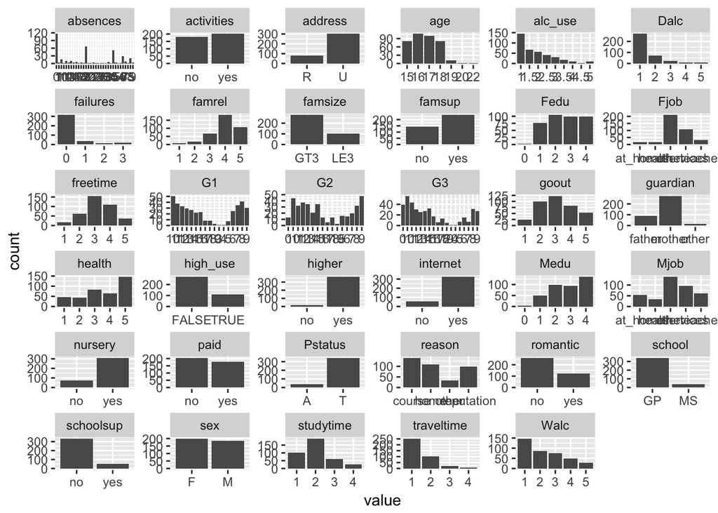

## Hypothesis

1. Hypothesis of absences:  
   H0: High absences are related to high alcohol consumption  
   H1: More absences aren’t related to high alcohol consumption
2. Hypothesis of health:  
   H0: Poor health is related to high alcohol consumption  
   H1: Poor health isn’t related to high alcohol consumption
3. Hypothesis of failures:  
   H0: More failures are related to high alcohol consumption  
   H1: Failures aren’t related to high alcohol consumption
4. Hypothesis of activities:  
   H0: No activities is related to high alcohol consumption  
   H1: Activities are related to high alcohol consumption

Absenses:  
I divided absences to logical type variable absences_high that is true if student have more than three absences (3.00 is the median value for absences).

```
## Source: local data frame [4 x 4]
## Groups: absences_high [?]
##
##   absences_high high_use count mean_grade
##           <lgl>    <lgl> <int>      <dbl>
## 1         FALSE    FALSE   152   9.848684
## 2         FALSE     TRUE    40   9.850000
## 3          TRUE    FALSE   118  11.322034
## 4          TRUE     TRUE    72  10.291667
```

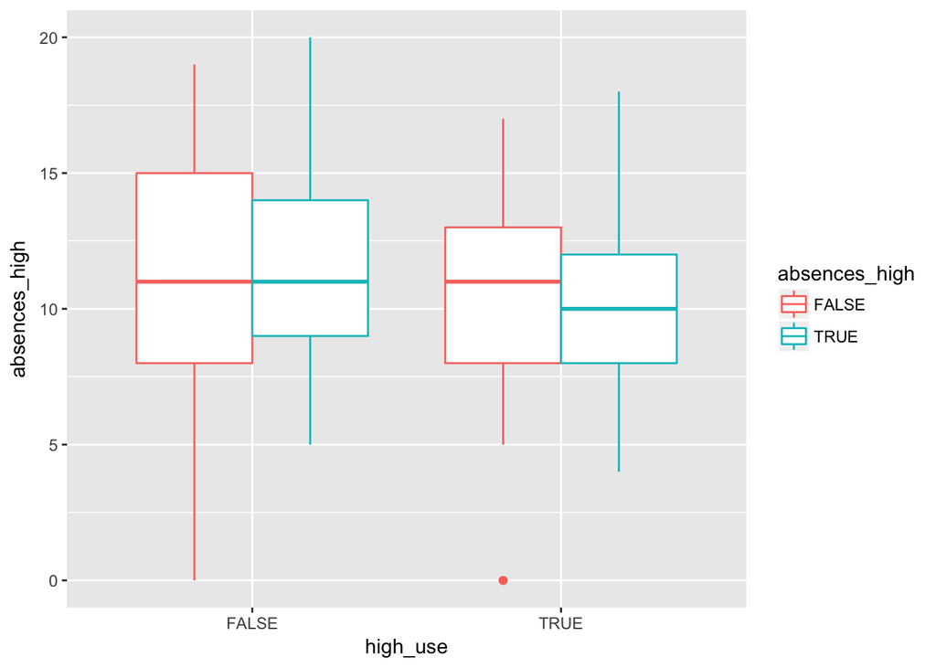

Health:

```
## Source: local data frame [4 x 4]
## Groups: health_poor [?]
##
##   health_poor high_use count mean_grade
##         <lgl>    <lgl> <int>      <dbl>
## 1       FALSE    FALSE   206   10.25243
## 2       FALSE     TRUE    87   10.16092
## 3        TRUE    FALSE    64   11.26562
## 4        TRUE     TRUE    25   10.04000
```

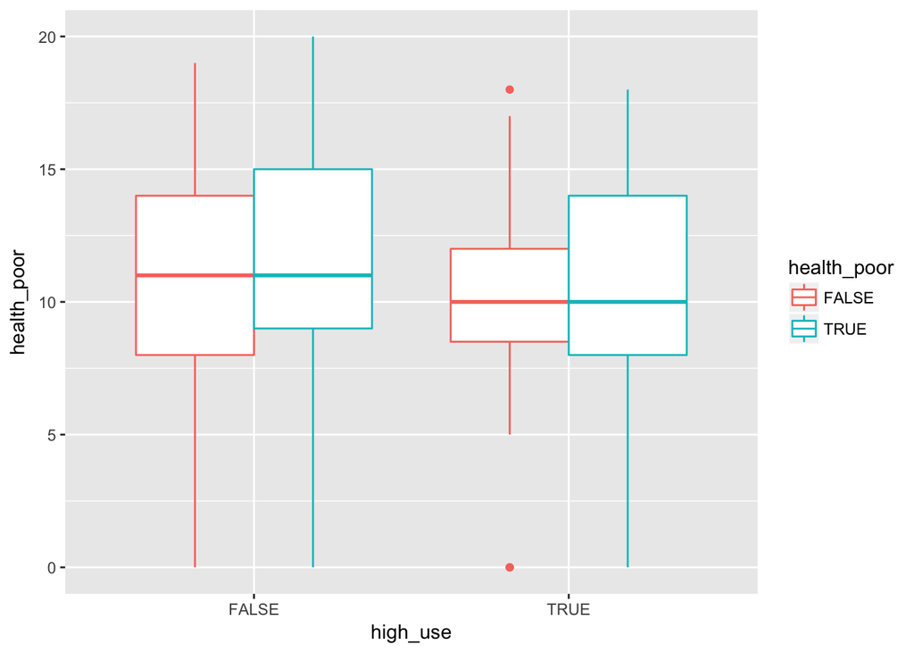

Seems that poor health has very limited impact on course grades with or without high alcohol consumption.

Failures:

```
## Source: local data frame [4 x 4]
## Groups: failures_high [?]
##
##   failures_high high_use count mean_grade
##           <lgl>    <lgl> <int>      <dbl>
## 1         FALSE    FALSE   256  10.859375
## 2         FALSE     TRUE    98  10.622449
## 3          TRUE    FALSE    14   3.785714
## 4          TRUE     TRUE    14   6.714286
```

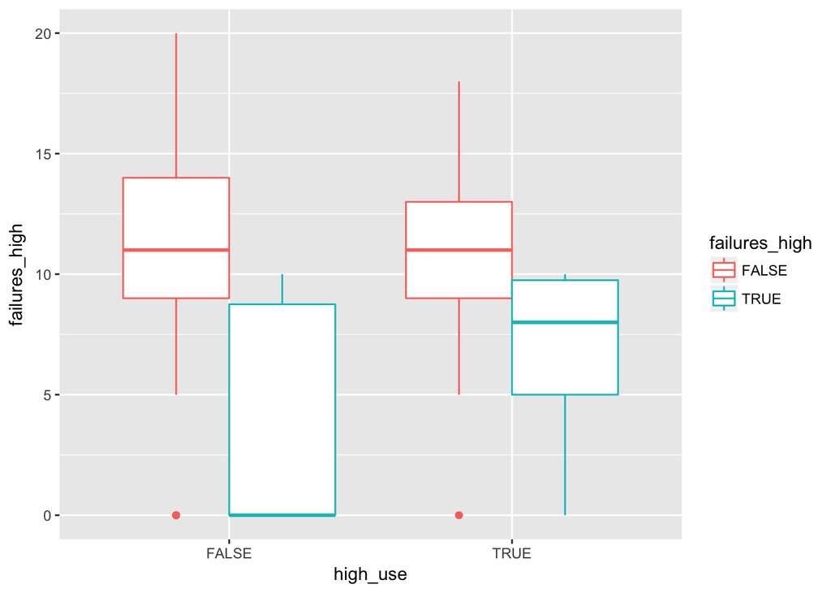

This is maybe the most interesting discovery in the data: those students that had more failures (=more than one) had tendency to use more alcohol althougth the variance for many failures and low alcohol consumption was wide.

Activities:

```
## Source: local data frame [4 x 4]
## Groups: activities [?]
##
##   activities high_use count mean_grade
##       <fctr>    <lgl> <int>      <dbl>
## 1         no    FALSE   122   10.23770
## 2         no     TRUE    59   10.06780
## 3        yes    FALSE   148   10.70270
## 4        yes     TRUE    53   10.20755
```

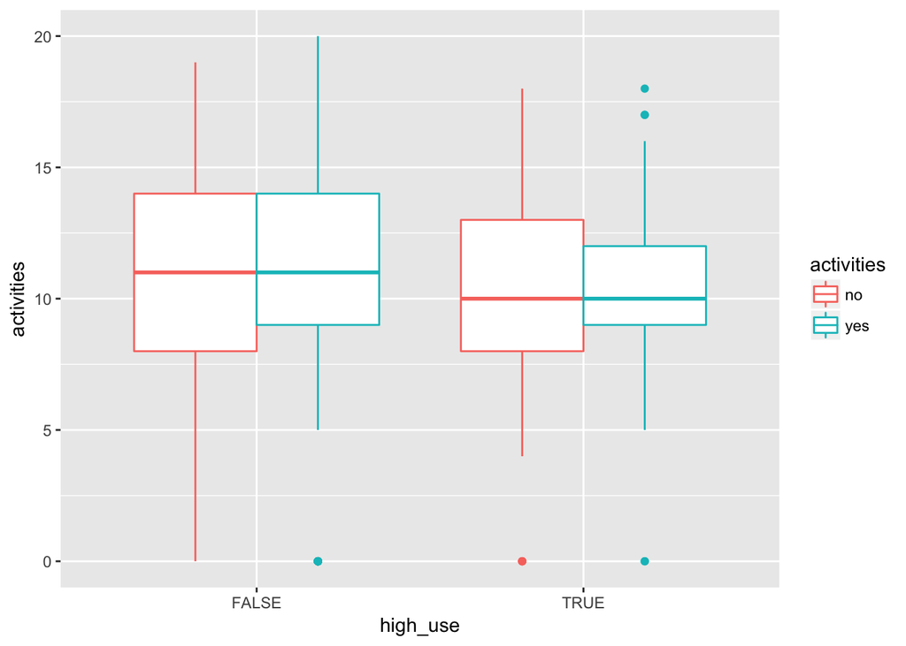

Activities didn’t had any significant impact on alcohol usage and course grades.

```
##         prediction
## high_use FALSE TRUE
##    FALSE   267    3
##    TRUE    103    9
```

```
## [1] 0.2774869
```

The average number of wrong predictions is 0.2774869.

```
## [1] 0.2774869
```

```
## [1] 0.2774869
```